# Predicción de subtipos de cáncer de piel

Sara Álvarez Estévez

2024-06-14

# Introducción

El cáncer es una enfermedad caracterizada por el crecimiento descontrolado de células anormales en el cuerpo. Estas células pueden invadir y destruir el tejido sano circundante y, en algunos casos, diseminarse a otras partes del cuerpo a través del sistema linfático o sanguíneo, un proceso conocido como metástasis.

El desarrollo del cáncer generalmente implica una serie de cambios genéticos que pueden ser heredados, causados por factores ambientales, o resultar de errores en la replicación del ADN. Estos cambios afectan genes que regulan el crecimiento y división celular, como oncogenes (que promueven el crecimiento celular) y genes supresores de tumores (que frenan el crecimiento celular). Estos cambios genéticos pueden ser detectados a través del análisis de la expresión del mRNA.

El estudio que se presenta corresponde a 150 muestras de RNA-seq de tejido epitelial con cáncer, que han sido normalizados y prefiltrados. Los datos estan recogidos en el fichero rna1.csv. La primera columna contiene el subtipo de cáncer de piel: tipus1, tipus2 y tipus 3 y el resto de columnas la expresión normalizada de genes preseleccionados.

# Objetivo

El objetivo es predecir el subtipo de cáncer de piel de los pacientes a partir de la información recogida en un estudio de RNA-seq.

# Obtención de los datos

```r
rna1<- read.csv("rna1.csv")
```

# Análisis Exploratorio

```r
dim(rna1)
```

```
[1] 150 201
```

Vemos que tenemos un dataset con 201 variables provenientes de 150 muestras.

Comprobamos si hay valores ausentes:

```r
table(is.na(rna1))
```

```
FALSE
30150
```

No existen valores ausentes en el dataset, por lo que podemos seguir con nuestro análisis exploratorio. Primero comprobamos cuantos registros tenemos para cada tipo de cáncer

```r
table(rna1$Class)
```

```
tipus1 tipus2 tipus3
    45     30     75
```

Vemos que tenemos un tamaño muestral similar para el tipo 1 y el tipo 2, mientras que tenemos bastantes más muestras en el tipo 3.

A continuación, puede ser interesante observar la distribución de las distintas variables.

```r
summary(rna1[c(1:3,20:23,199:201)])
```

```
    Class                RTN2            NDRG2            ARL4C
 Length:150         Min.   :0.3328   Min.   : 3.311   Min.   :1.509
 Class :character   1st Qu.:2.8110   1st Qu.: 4.997   1st Qu.:5.117
 Mode  :character   Median :3.6499   Median : 5.889   Median :5.752
                    Mean   :3.5493   Mean   : 6.010   Mean   :5.648
                    3rd Qu.:4.3936   3rd Qu.: 6.821   3rd Qu.:6.258
                    Max.   :6.1429   Max.   :10.260   Max.   :9.427
     HTRA1            KIF13B          CPPED1           JAM3
 Min.   : 4.593   Min.   :2.598   Min.   :2.015   Min.   :2.146
 1st Qu.: 6.823   1st Qu.:5.005   1st Qu.:4.446   1st Qu.:3.999
 Median : 7.780   Median :5.909   Median :5.111   Median :4.625
 Mean   : 7.612   Mean   :5.966   Mean   :5.043   Mean   :4.553
 3rd Qu.: 8.546   3rd Qu.:7.026   3rd Qu.:5.776   3rd Qu.:5.258
 Max.   :10.089   Max.   :8.853   Max.   :7.180   Max.   :6.838
     ZNF680           PBX1
 Min.   :1.825   Min.   : 5.026
 1st Qu.:3.551   1st Qu.: 7.652
 Median :4.029   Median : 8.309
 Mean   :4.065   Mean   : 8.180
 3rd Qu.:4.602   3rd Qu.: 8.818
 Max.   :6.256   Max.   :10.674
```

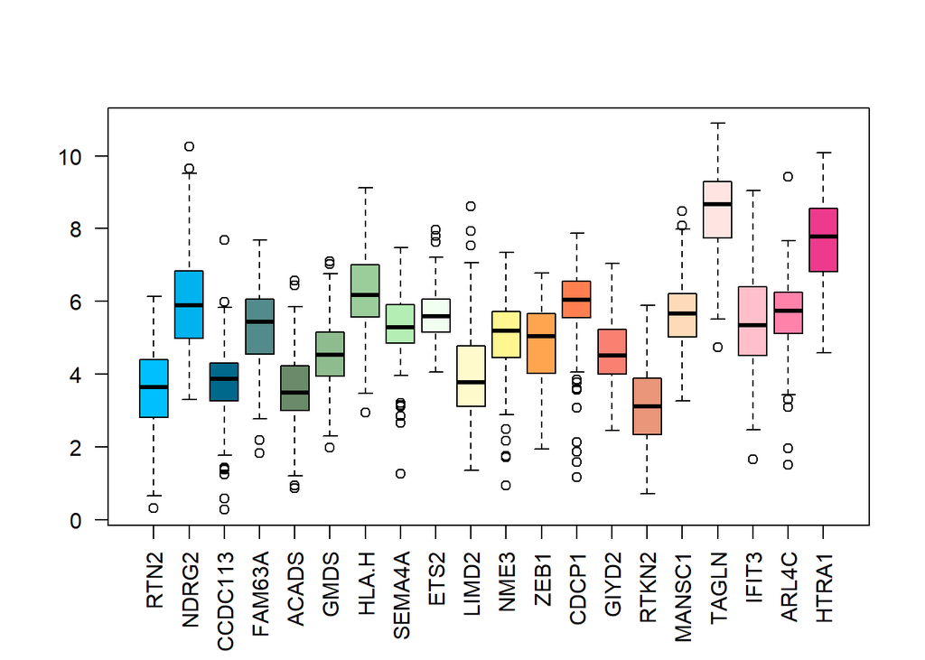

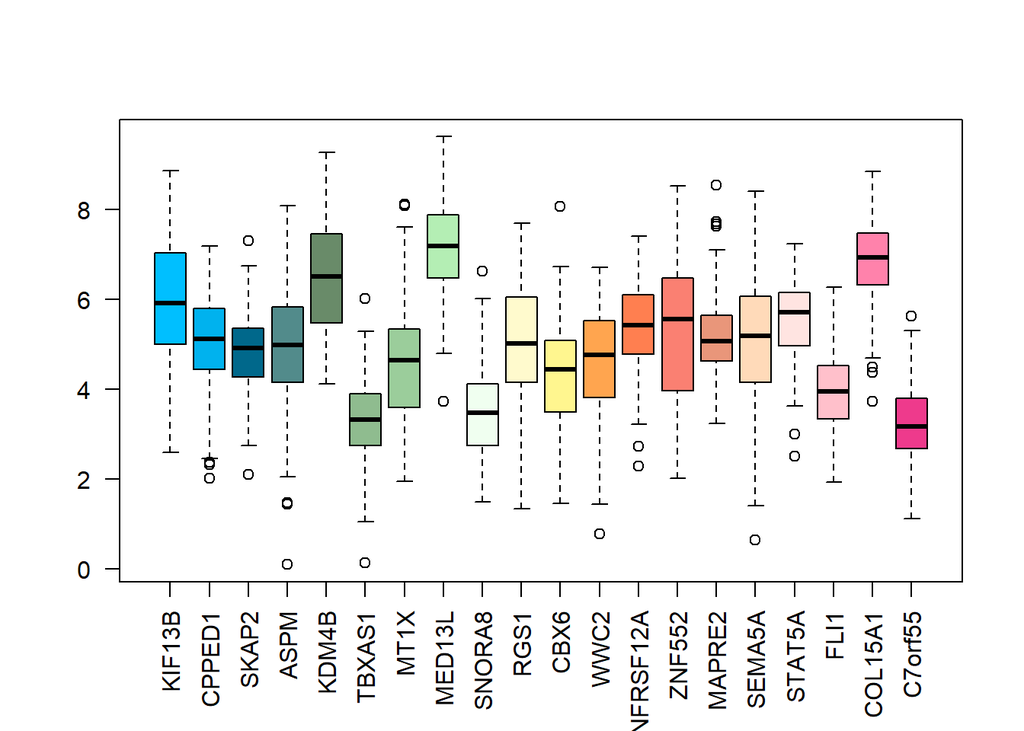

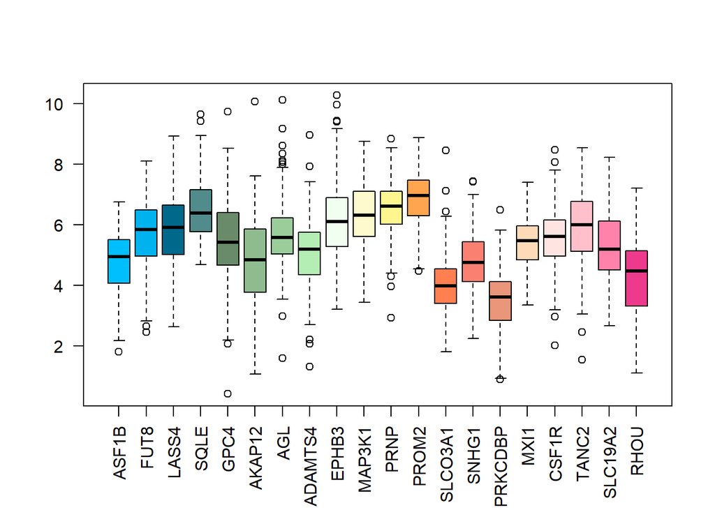

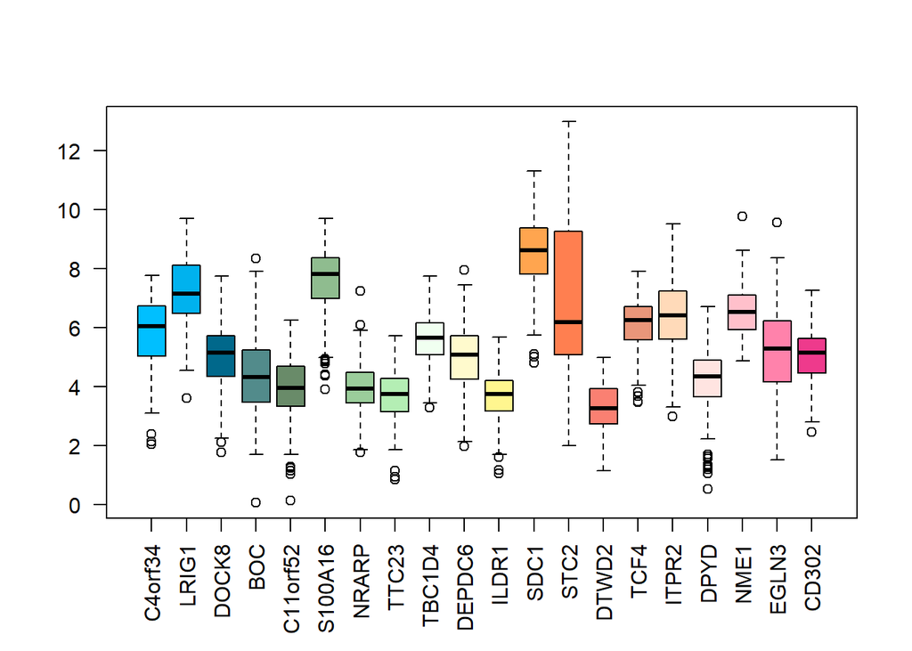

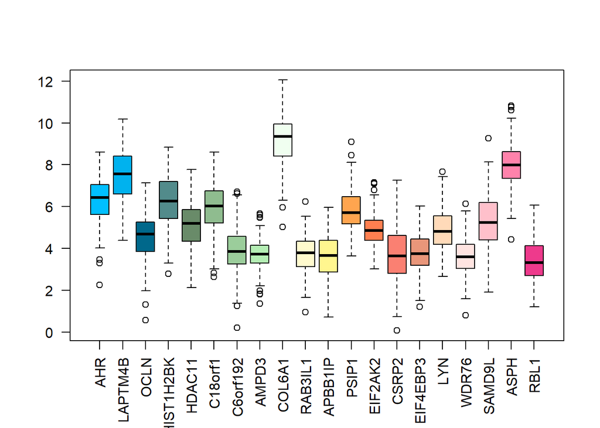

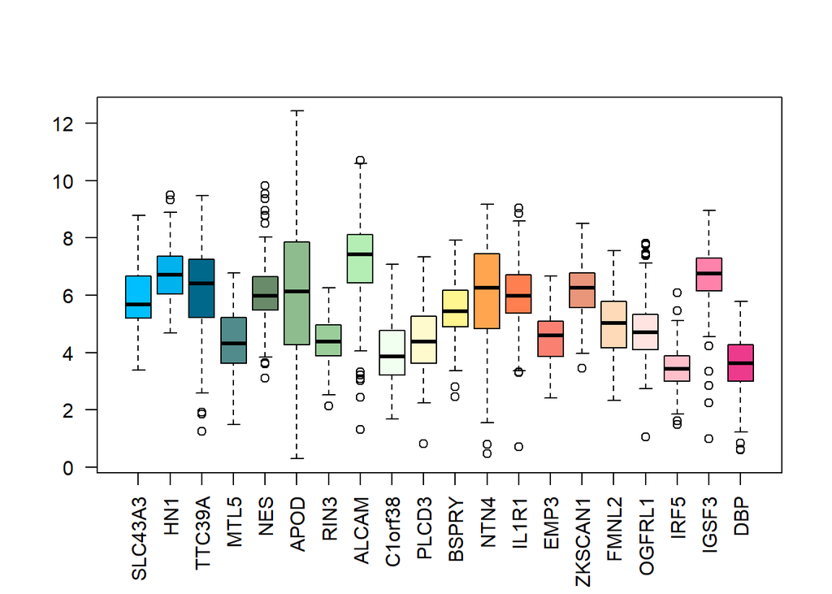

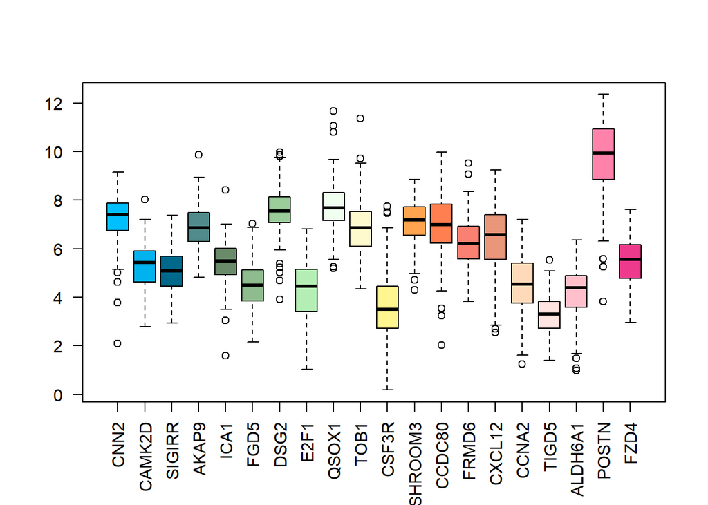

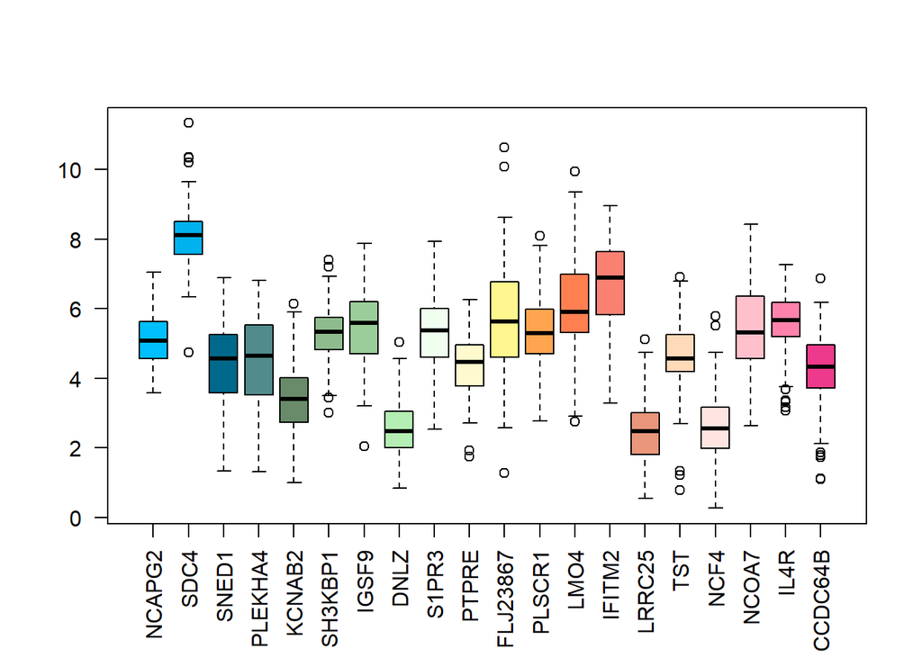

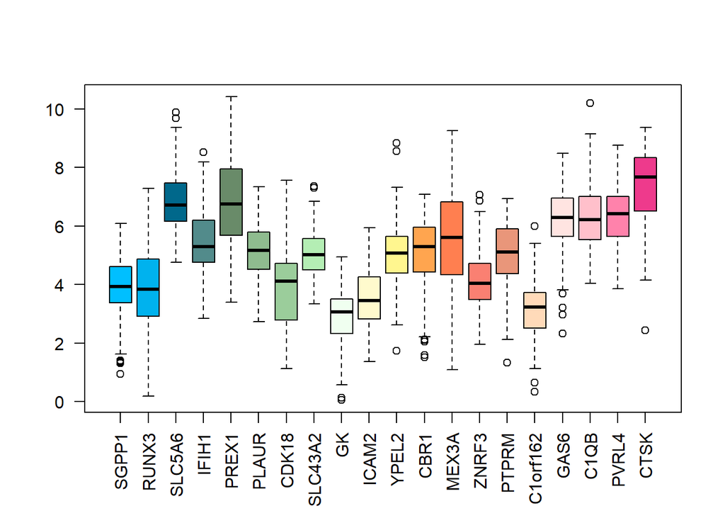

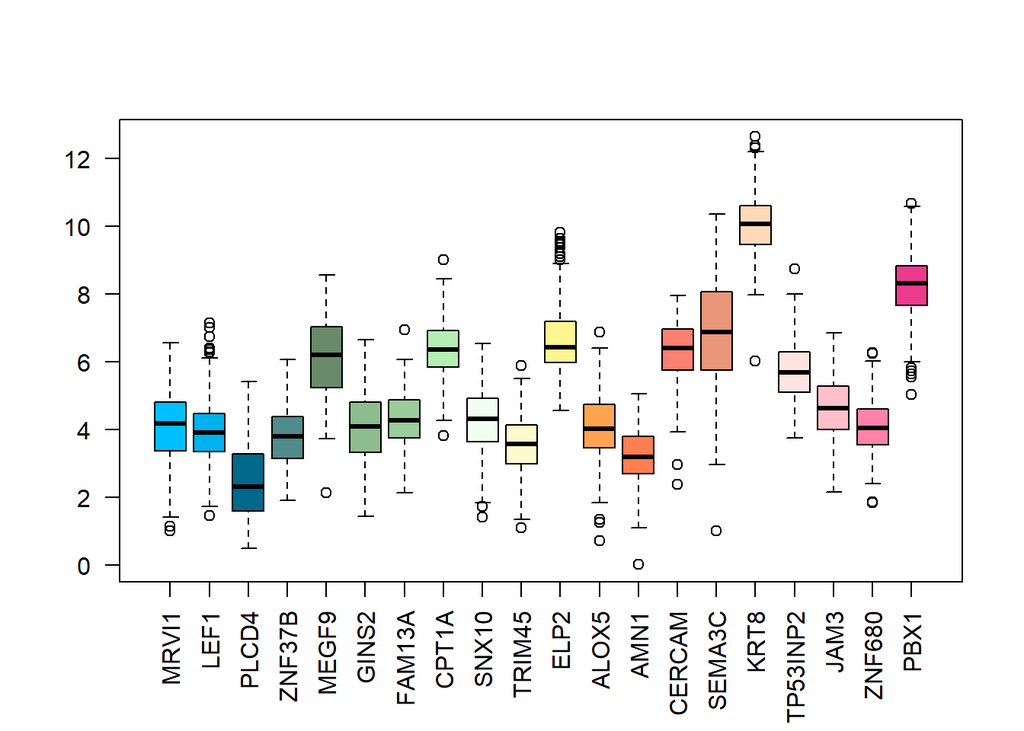

```r
col <- c("deepskyblue", "deepskyblue2","deepskyblue4", "darkslategray4", "darkseagreen4", "darkseagreen", "darkseagreen3","darkseagreen2","honeydew", "lemonchiffon","khaki1", "tan1", "coral", "salmon", "darksalmon", "peachpuff", "mistyrose", "pink", "palevioletred1","violetred2")
i <- 2
while (i <=182){
  boxplot(rna1[i:(i+19)], las = 2, col = col)
  i <- i+20
}
```

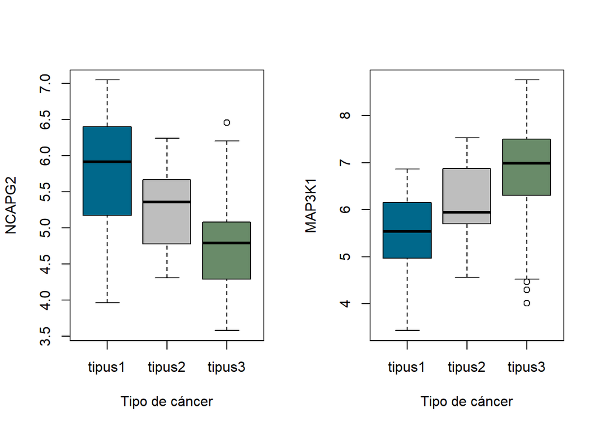

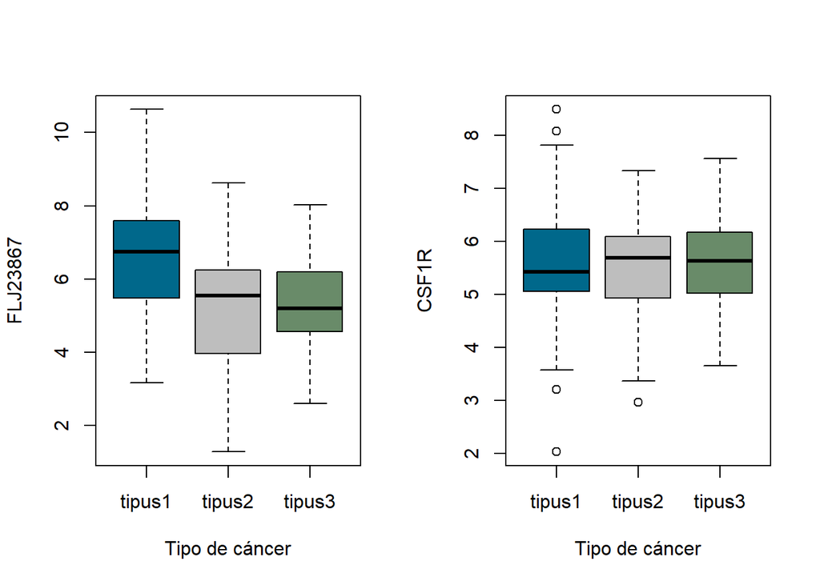

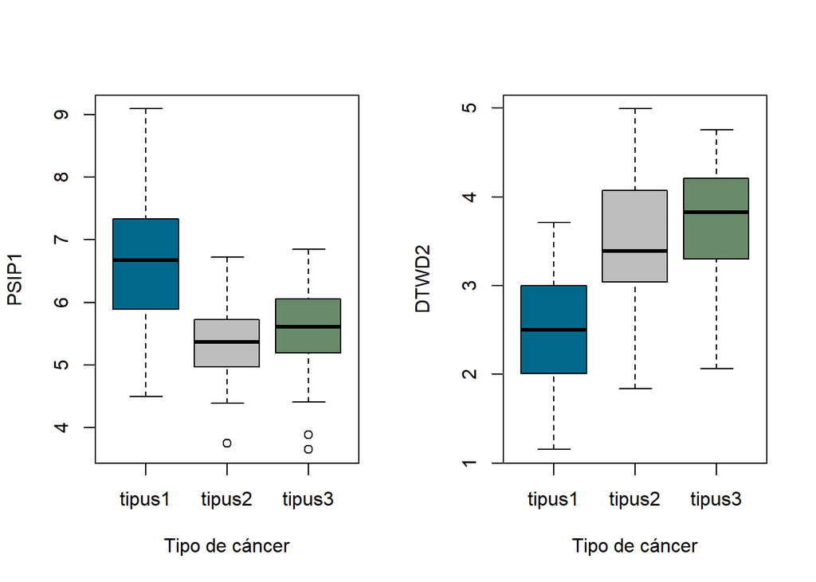

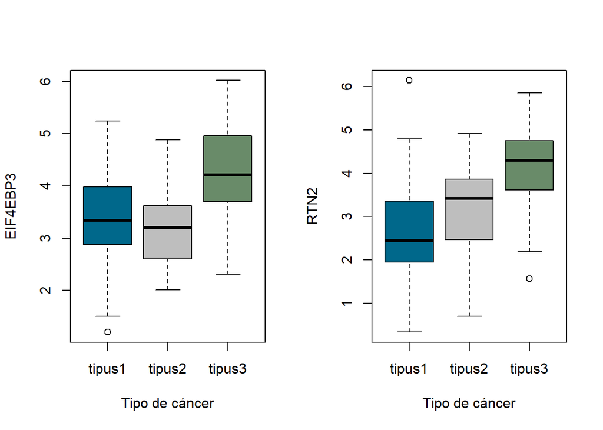

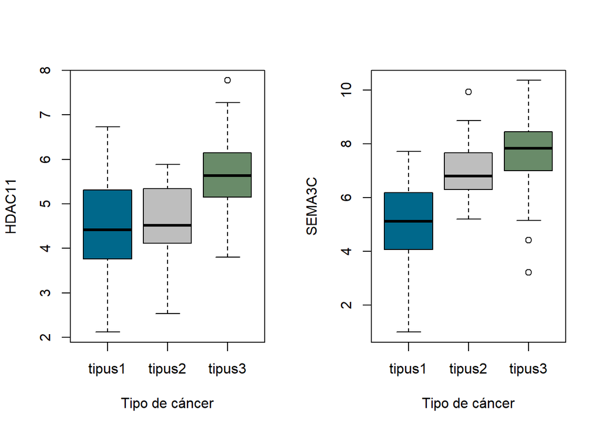

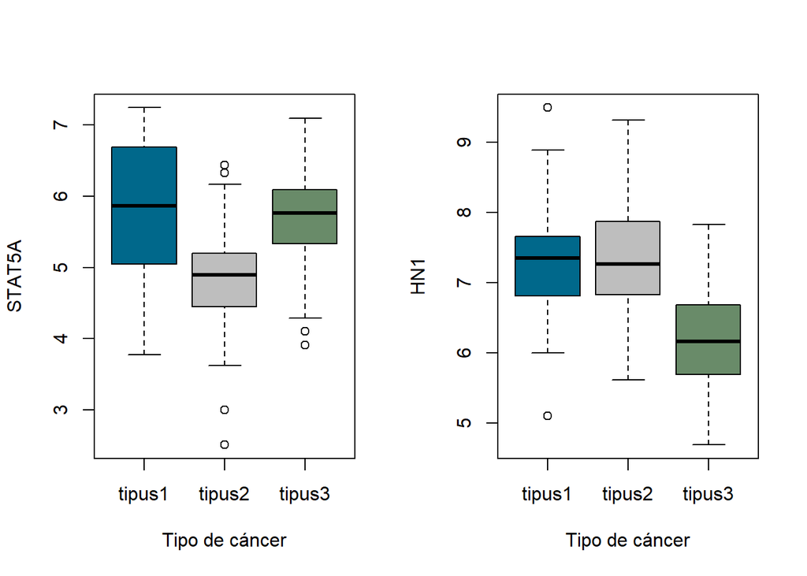

```r
set.seed(12345)
par(mfrow=c(1,2))
nums <- sample(201,12)
for (i in nums){
  boxplot(rna1[,i]~rna1[,1], xlab = "Tipo de cáncer", ylab = colnames(rna1[i]), col = c("deepskyblue4", "gray","darkseagreen4"))
}
```

Visualizamos la distribución de las expresiones de algunos de los genes según el tipo de cáncer, y, como podemos observar, para algunos de estos genes su expresión varía bastante de un grupo a otro. Otros, como el CSF1R tienen una distribución muy similar entre los distintos grupos.

# Análisis de componentes principales

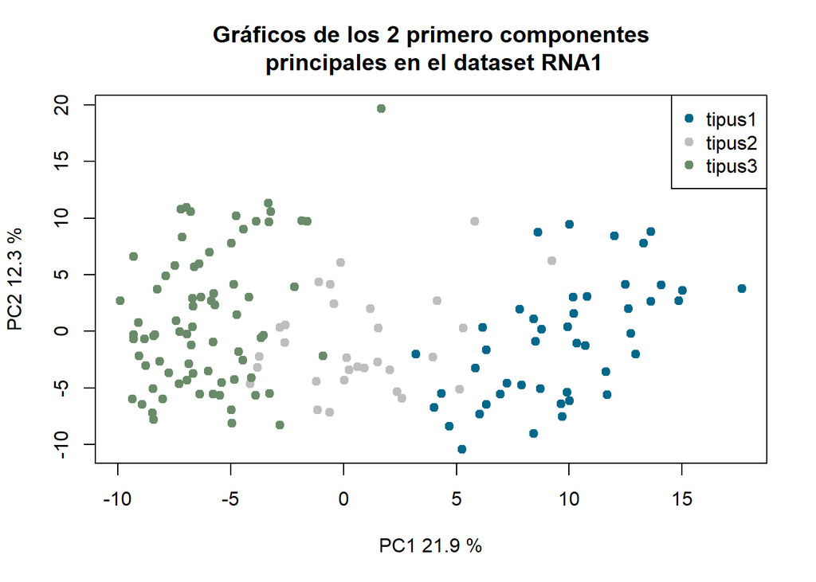

```r
cprna <- prcomp(rna1[-1])
# calculamos el porcentaje de variación explicado por cada componente principal
loads <- round(cprna$sdev^2/sum(cprna$sdev^2)*100,1)

# representamos gráficamente las diferentes muestras según sus dos primeros CPs.
xlab <- c(paste("PC1",loads[1],"%"))
ylab <- c(paste("PC2",loads[2],"%"))
colores<- c("deepskyblue4","gray","darkseagreen4")
plot(cprna$x[,1:2], xlab = xlab, ylab = ylab, col = colores[factor(rna1$Class)], pch = 19)
title("Gráficos de los 2 primero componentes\n principales en el dataset RNA1")
legend("topright", legend = levels(factor(rna1$Class)),
      pch = 19,
      col = colores,
      cex = 1)
```

Vemos una clara separación por grupos a lo largo del eje horizontal, ya que las muetsras de tipo 1 tienen a estar hacia la derecha, las de tipo 2 en la zona central y las de tipo 3 en la izquierda.

# Preparación de los datos

Para comenzar, como algunos de los algoritmos que utilizaremos solo aceptan variables numéricas o categóricas, transformaremos la variable `Class` de `character` a `factor`:

```r
rna1$Class <- as.factor(rna1$Class)
```

A continuación, crearemos nuestro training y test datasets dividiendo los datos en 2/3 training y 1/3 test.

```r
set.seed(12345)
ntrain <- (2/3)*length(rna1$RTN2)
numtrain <- sample(length(rna1$RTN2),ntrain)
# para algunos algoritmos podremos utilizar el dataset completo y dividir únicamente en training y test
rna1ds_train <- rna1[numtrain,]
rna1ds_test <- rna1[-numtrain,]
# mientras que en otros necesitaremos separar los datos de sus estiquetas.
rna1_train <- rna1[numtrain,-1]
rna1_test <- rna1[-numtrain,-1]
labels_train <- rna1[numtrain,1]
labels_test <- rna1[-numtrain,1]
```

Comprobamos que hay una distribución similar de los tres tipos de cáncer tanto en el train como en el test dataset.

```r
prop.table(table(rna1ds_train$Class))
```

```
tipus1 tipus2 tipus3
  0.32   0.19   0.49
```

```r
prop.table(table(rna1ds_test$Class))
```

```
tipus1 tipus2 tipus3
  0.26   0.22   0.52
```

# Entrenando los modelos sobre los datos

En esta sección probaremos diferentes clasificadores para los datos sobre el cáncer de piel:

## k-Nearest Neighbour (k-NN)

Antes de aplicar el algoritmo k-NN necesitamos normalizar los datos. Esto de debe a que este algoritmo, se basa en el cálculo de distancias, y estas distancias son altamente dependientes de como son memdidas las características. Si una de nuestras variables tiene un rango de valores mucho más alto que otra, la medida de la distancia se verá dominada por esta. Como pudimos observar en el análisis exploratorio, algunos de los genes tienen distribuciones muy distintas entre sí, por lo que optaremos por la normalización de los datos:

```r
# creamos na función de normalización minmax
normalize <- function(x){
  return((x-min(x))/(max(x)-min(x)))
}
```

De esta forma, ahora todos los valores oscilaran entre 0 y 1.

```r
rna_train_n <- as.data.frame(lapply(rna1_train,normalize))
rna_test_n <- as.data.frame(lapply(rna1_test,normalize))
```

Comprobamos la correcta normalización con alguna de las variables:

```r
summary(rna_train_n$RTN2)
```

```
   Min. 1st Qu.  Median    Mean 3rd Qu.    Max.
 0.0000  0.4518  0.6066  0.5792  0.7304  1.0000
```

```r
summary(rna_test_n$RTN2)
```

```
   Min. 1st Qu.  Median    Mean 3rd Qu.    Max.
 0.0000  0.3764  0.5230  0.5289  0.7004  1.0000
```

```r
library(class)
library(caret)
knn1 <- knn(train = rna_train_n, test = rna_test_n, cl = labels_train, k = 1)
confusionMatrix(knn1, labels_test)
```

```
Confusion Matrix and Statistics

          Reference
Prediction tipus1 tipus2 tipus3
    tipus1     13      0      0
    tipus2      0      9      0
    tipus3      0      2     26

Overall Statistics

               Accuracy : 0.96
                 95% CI : (0.8629, 0.9951)
    No Information Rate : 0.52
    P-Value [Acc > NIR] : 6.886e-12

                  Kappa : 0.9335

 Mcnemar's Test P-Value : NA

Statistics by Class:

                     Class: tipus1 Class: tipus2 Class: tipus3
Sensitivity                   1.00        0.8182        1.0000
Specificity                   1.00        1.0000        0.9167
Pos Pred Value                1.00        1.0000        0.9286
Neg Pred Value                1.00        0.9512        1.0000
Prevalence                    0.26        0.2200        0.5200
Detection Rate                0.26        0.1800        0.5200
Detection Prevalence          0.26        0.1800        0.5600
Balanced Accuracy             1.00        0.9091        0.9583
```

```r
knn3 <- knn(train = rna_train_n, test = rna_test_n, cl = labels_train, k = 3)
confusionMatrix(knn3, labels_test)
```

```
Confusion Matrix and Statistics

          Reference
Prediction tipus1 tipus2 tipus3
    tipus1     13      1      0
    tipus2      0      6      0
    tipus3      0      4     26

Overall Statistics

               Accuracy : 0.9
                 95% CI : (0.7819, 0.9667)
    No Information Rate : 0.52
    P-Value [Acc > NIR] : 1.012e-08

                  Kappa : 0.8302

 Mcnemar's Test P-Value : NA

Statistics by Class:

                     Class: tipus1 Class: tipus2 Class: tipus3
Sensitivity                 1.0000        0.5455        1.0000
Specificity                 0.9730        1.0000        0.8333
Pos Pred Value              0.9286        1.0000        0.8667
Neg Pred Value              1.0000        0.8864        1.0000
Prevalence                  0.2600        0.2200        0.5200
Detection Rate              0.2600        0.1200        0.5200
Detection Prevalence        0.2800        0.1200        0.6000
Balanced Accuracy           0.9865        0.7727        0.9167
```

```r
knn5 <- knn(train = rna_train_n, test = rna_test_n, cl = labels_train, k = 5)
confusionMatrix(knn5, labels_test)
```

```
Confusion Matrix and Statistics

          Reference
Prediction tipus1 tipus2 tipus3
    tipus1     13      1      0
    tipus2      0      7      0
    tipus3      0      3     26

Overall Statistics

               Accuracy : 0.92
                 95% CI : (0.8077, 0.9778)
    No Information Rate : 0.52
    P-Value [Acc > NIR] : 1.16e-09

                  Kappa : 0.8655

 Mcnemar's Test P-Value : NA

Statistics by Class:

                     Class: tipus1 Class: tipus2 Class: tipus3
Sensitivity                 1.0000        0.6364        1.0000
Specificity                 0.9730        1.0000        0.8750
Pos Pred Value              0.9286        1.0000        0.8966
Neg Pred Value              1.0000        0.9070        1.0000
Prevalence                  0.2600        0.2200        0.5200
Detection Rate              0.2600        0.1400        0.5200
Detection Prevalence        0.2800        0.1400        0.5800
Balanced Accuracy           0.9865        0.8182        0.9375
```

```r
knn7 <- knn(train = rna_train_n, test = rna_test_n, cl = labels_train, k = 7)
confusionMatrix(knn7, labels_test)
```

```
Confusion Matrix and Statistics

          Reference
Prediction tipus1 tipus2 tipus3
    tipus1     13      1      0
    tipus2      0      6      0
    tipus3      0      4     26

Overall Statistics

               Accuracy : 0.9
                 95% CI : (0.7819, 0.9667)
    No Information Rate : 0.52
    P-Value [Acc > NIR] : 1.012e-08

                  Kappa : 0.8302

 Mcnemar's Test P-Value : NA

Statistics by Class:

                     Class: tipus1 Class: tipus2 Class: tipus3
Sensitivity                 1.0000        0.5455        1.0000
Specificity                 0.9730        1.0000        0.8333
Pos Pred Value              0.9286        1.0000        0.8667
Neg Pred Value              1.0000        0.8864        1.0000
Prevalence                  0.2600        0.2200        0.5200
Detection Rate              0.2600        0.1200        0.5200
Detection Prevalence        0.2800        0.1200        0.6000
Balanced Accuracy           0.9865        0.7727        0.9167
```

```r
knn11 <- knn(train = rna_train_n, test = rna_test_n, cl = labels_train, k = 11)
confusionMatrix(knn11, labels_test)
```

```
Confusion Matrix and Statistics

          Reference
Prediction tipus1 tipus2 tipus3
    tipus1     13      1      0
    tipus2      0      7      0
    tipus3      0      3     26

Overall Statistics

               Accuracy : 0.92
                 95% CI : (0.8077, 0.9778)
    No Information Rate : 0.52
    P-Value [Acc > NIR] : 1.16e-09

                  Kappa : 0.8655

 Mcnemar's Test P-Value : NA

Statistics by Class:

                     Class: tipus1 Class: tipus2 Class: tipus3
Sensitivity                 1.0000        0.6364        1.0000
Specificity                 0.9730        1.0000        0.8750
Pos Pred Value              0.9286        1.0000        0.8966
Neg Pred Value              1.0000        0.9070        1.0000
Prevalence                  0.2600        0.2200        0.5200
Detection Rate              0.2600        0.1400        0.5200
Detection Prevalence        0.2800        0.1400        0.5800
Balanced Accuracy           0.9865        0.8182        0.9375
```

|  | Accuracy | Kappa | Sensibilidad T1 | Especificidad T1 | Sensibilidad T2 | Especificidad T2 | Sensibilidad T3 | Especificidad T3 |
| --- | --- | --- | --- | --- | --- | --- | --- | --- |
| K=1 | 0.96 | 0.9335106 | 1 | 1.000000 | 0.8181818 | 1 | 1 | 0.9166667 |
| K=3 | 0.90 | 0.8301630 | 1 | 0.972973 | 0.5454545 | 1 | 1 | 0.8333333 |
| K=5 | 0.92 | 0.8655010 | 1 | 0.972973 | 0.6363636 | 1 | 1 | 0.8750000 |
| K=7 | 0.90 | 0.8301630 | 1 | 0.972973 | 0.5454545 | 1 | 1 | 0.8333333 |
| K=11 | 0.92 | 0.8655010 | 1 | 0.972973 | 0.6363636 | 1 | 1 | 0.8750000 |

## NaiveBayes

```r
library(e1071)
rna_naiveB <- naiveBayes(rna1_train, labels_train, laplace = 0)
```

```r
rna_naiveB_pred <- predict(rna_naiveB, rna1_test)
confusionMatrix(rna_naiveB_pred, labels_test)
```

```
Confusion Matrix and Statistics

          Reference
Prediction tipus1 tipus2 tipus3
    tipus1     13      2      0
    tipus2      0      8      0
    tipus3      0      1     26

Overall Statistics

               Accuracy : 0.94
                 95% CI : (0.8345, 0.9875)
    No Information Rate : 0.52
    P-Value [Acc > NIR] : 1.042e-10

                  Kappa : 0.901

 Mcnemar's Test P-Value : NA

Statistics by Class:

                     Class: tipus1 Class: tipus2 Class: tipus3
Sensitivity                 1.0000        0.7273        1.0000
Specificity                 0.9459        1.0000        0.9583
Pos Pred Value              0.8667        1.0000        0.9630
Neg Pred Value              1.0000        0.9286        1.0000
Prevalence                  0.2600        0.2200        0.5200
Detection Rate              0.2600        0.1600        0.5200
Detection Prevalence        0.3000        0.1600        0.5400
Balanced Accuracy           0.9730        0.8636        0.9792
```

```r
rna_naiveB1 <- naiveBayes(rna1_train, labels_train, laplace = 1)
rna_naiveB_pred1 <- predict(rna_naiveB1, rna1_test)
confusionMatrix(rna_naiveB_pred1, labels_test)
```

```
Confusion Matrix and Statistics

          Reference
Prediction tipus1 tipus2 tipus3
    tipus1     13      2      0
    tipus2      0      8      0
    tipus3      0      1     26

Overall Statistics

               Accuracy : 0.94
                 95% CI : (0.8345, 0.9875)
    No Information Rate : 0.52
    P-Value [Acc > NIR] : 1.042e-10

                  Kappa : 0.901

 Mcnemar's Test P-Value : NA

Statistics by Class:

                     Class: tipus1 Class: tipus2 Class: tipus3
Sensitivity                 1.0000        0.7273        1.0000
Specificity                 0.9459        1.0000        0.9583
Pos Pred Value              0.8667        1.0000        0.9630
Neg Pred Value              1.0000        0.9286        1.0000
Prevalence                  0.2600        0.2200        0.5200
Detection Rate              0.2600        0.1600        0.5200
Detection Prevalence        0.3000        0.1600        0.5400
Balanced Accuracy           0.9730        0.8636        0.9792
```

|  | Accuracy | Kappa | Sensibilidad T1 | Especificidad T1 | Sensibilidad T2 | Especificidad T2 | Sensibilidad T3 | Especificidad T3 |
| --- | --- | --- | --- | --- | --- | --- | --- | --- |
| Laplace = 0 | 0.94 | 0.9009901 | 1 | 0.9459459 | 0.7272727 | 1 | 1 | 0.9583333 |
| Laplace = 1 | 0.94 | 0.9009901 | 1 | 0.9459459 | 0.7272727 | 1 | 1 | 0.9583333 |

En este caso observamos que tanto con el valor de laplace 0 o 1, obtenemos el mismo resultado.

## Neural network

La parte de Neural Network se encuentra en el archivo adjunto python notebook, ya que por problemas de almacenamiento en el dispositivo no me permite utilizar keras ni tensorflow en R.

|  | Accuracy | Kappa | Sensibilidad T1 | Especificidad T1 | Sensibilidad T2 | Especificidad T2 | Sensibilidad T3 | Especificidad T3 |
| --- | --- | --- | --- | --- | --- | --- | --- | --- |
| 1 capa oculta 30 nodos | 0.92 |  | 1 | 0.93 | 0.88 | 0.7 | 0.89 | 1 |
| 2 capas ocultas 50 y 30 nodos | 0.94 |  | 1 | 0.93 | 0.89 | 0.8 | 0.93 | 1 |

Podemos ver que aunque ambas redes dan muy buenos resultados, estos son ligeramente mejores cuando trabajamos con dos capas ocultas.

## Suppor Vector Machine

```r
library(kernlab)
# modelo lineal
cancer_linear_classifier <- ksvm(Class ~., data = rna1ds_train, kernel = "vanilladot")
cancer_linear_classifier
```

```
Support Vector Machine object of class "ksvm"

SV type: C-svc  (classification)
 parameter : cost C = 1

Linear (vanilla) kernel function.

Number of Support Vectors : 47

Objective Function Value : -0.0639 -0.0288 -0.0824
Training error : 0
```

```r
linear_predictions <- predict(cancer_linear_classifier, rna1ds_test)
confusionMatrix(linear_predictions, labels_test)
```

```
Confusion Matrix and Statistics

          Reference
Prediction tipus1 tipus2 tipus3
    tipus1     13      1      0
    tipus2      0      8      0
    tipus3      0      2     26

Overall Statistics

               Accuracy : 0.94
                 95% CI : (0.8345, 0.9875)
    No Information Rate : 0.52
    P-Value [Acc > NIR] : 1.042e-10

                  Kappa : 0.9001

 Mcnemar's Test P-Value : NA

Statistics by Class:

                     Class: tipus1 Class: tipus2 Class: tipus3
Sensitivity                 1.0000        0.7273        1.0000
Specificity                 0.9730        1.0000        0.9167
Pos Pred Value              0.9286        1.0000        0.9286
Neg Pred Value              1.0000        0.9286        1.0000
Prevalence                  0.2600        0.2200        0.5200
Detection Rate              0.2600        0.1600        0.5200
Detection Prevalence        0.2800        0.1600        0.5600
Balanced Accuracy           0.9865        0.8636        0.9583
```

```r
# modelo gausiano
cancer_gaussian_classifier <- ksvm (Class ~., data = rna1ds_train, kernel = "rbfdot")
cancer_gaussian_classifier
```

```
Support Vector Machine object of class "ksvm"

SV type: C-svc  (classification)
 parameter : cost C = 1

Gaussian Radial Basis kernel function.
 Hyperparameter : sigma =  0.00336278880894285

Number of Support Vectors : 78

Objective Function Value : -13.0113 -9.4543 -15.9965
Training error : 0.01
```

```r
gaussian_predictions <- predict(cancer_gaussian_classifier, rna1ds_test)
confusionMatrix(gaussian_predictions, labels_test)
```

```
Confusion Matrix and Statistics

          Reference
Prediction tipus1 tipus2 tipus3
    tipus1     13      2      0
    tipus2      0      6      0
    tipus3      0      3     26

Overall Statistics

               Accuracy : 0.9
                 95% CI : (0.7819, 0.9667)
    No Information Rate : 0.52
    P-Value [Acc > NIR] : 1.012e-08

                  Kappa : 0.8316

 Mcnemar's Test P-Value : NA

Statistics by Class:

                     Class: tipus1 Class: tipus2 Class: tipus3
Sensitivity                 1.0000        0.5455        1.0000
Specificity                 0.9459        1.0000        0.8750
Pos Pred Value              0.8667        1.0000        0.8966
Neg Pred Value              1.0000        0.8864        1.0000
Prevalence                  0.2600        0.2200        0.5200
Detection Rate              0.2600        0.1200        0.5200
Detection Prevalence        0.3000        0.1200        0.5800
Balanced Accuracy           0.9730        0.7727        0.9375
```

|  | Accuracy | Kappa | Sensibilidad T1 | Especificidad T1 | Sensibilidad T2 | Especificidad T2 | Sensibilidad T3 | Especificidad T3 |
| --- | --- | --- | --- | --- | --- | --- | --- | --- |
| Kernel lineal | 0.94 | 0.9001332 | 1 | 0.9729730 | 0.7272727 | 1 | 1 | 0.9166667 |
| Kernel rbf | 0.90 | 0.8316498 | 1 | 0.9459459 | 0.5454545 | 1 | 1 | 0.8750000 |

Vemos que el modelo que mejor se adapta a nuestros datos es aquel con un kernel lineal, ya que todas las métricas son iguales o más altas, viendo, de nuevo, una gran diferencia en la sensibilidad para el tipo 2, que disminuye de 0.727 a 0.545 cuando cambiamos el kernel.

## Árboles de clasificación

```r
library(C50)
cancerc50 <- C5.0(rna1_train, labels_train)
cancerc50
```

```
Call:
C5.0.default(x = rna1_train, y = labels_train)

Classification Tree
Number of samples: 100
Number of predictors: 200

Tree size: 7

Non-standard options: attempt to group attributes
```

```r
summary(cancerc50)
```

```
Call:
C5.0.default(x = rna1_train, y = labels_train)


C5.0 [Release 2.07 GPL Edition]     Wed Jun 26 12:19:50 2024
-------------------------------

Class specified by attribute `outcome'

Read 100 cases (201 attributes) from undefined.data

Decision tree:

ZNF552 <= 4.487574:
:...CBR1 <= 4.487009: tipus2 (4)
:   CBR1 > 4.487009: tipus1 (29)
ZNF552 > 4.487574:
:...C4orf34 <= 4.185863: tipus1 (3)
    C4orf34 > 4.185863:
    :...KDM4B <= 5.999684: tipus2 (10)
        KDM4B > 5.999684:
        :...STC2 <= 4.608363: tipus2 (3)
            STC2 > 4.608363:
            :...LAPTM4B <= 9.009091: tipus3 (49)
                LAPTM4B > 9.009091: tipus2 (2)


Evaluation on training data (100 cases):

        Decision Tree
      ----------------
      Size      Errors

         7    0( 0.0%)   <<


       (a)   (b)   (c)    <-classified as
      ----  ----  ----
        32                (a): class tipus1
              19          (b): class tipus2
                    49    (c): class tipus3


    Attribute usage:

    100.00% ZNF552
     67.00% C4orf34
     64.00% KDM4B
     54.00% STC2
     51.00% LAPTM4B
     33.00% CBR1


Time: 0.0 secs
```

```r
c50_pred <- predict(cancerc50, rna1_test)
confusionMatrix(c50_pred,labels_test)
```

```
Confusion Matrix and Statistics

          Reference
Prediction tipus1 tipus2 tipus3
    tipus1     11      3      1
    tipus2      2      6      2
    tipus3      0      2     23

Overall Statistics

               Accuracy : 0.8
                 95% CI : (0.6628, 0.8997)
    No Information Rate : 0.52
    P-Value [Acc > NIR] : 3.903e-05

                  Kappa : 0.6764

 Mcnemar's Test P-Value : 0.753

Statistics by Class:

                     Class: tipus1 Class: tipus2 Class: tipus3
Sensitivity                 0.8462        0.5455        0.8846
Specificity                 0.8919        0.8974        0.9167
Pos Pred Value              0.7333        0.6000        0.9200
Neg Pred Value              0.9429        0.8750        0.8800
Prevalence                  0.2600        0.2200        0.5200
Detection Rate              0.2200        0.1200        0.4600
Detection Prevalence        0.3000        0.2000        0.5000
Balanced Accuracy           0.8690        0.7214        0.9006
```

```r
c50boost10 <- C5.0(rna1_train, labels_train, trials = 10, control = C5.0Control(earlyStopping = FALSE))
c50boost10
```

[output not shown]

```r
summary(c50boost10)
```

```
Call:
C5.0.default(x = rna1_train, y = labels_train, trials = 10, control
 = C5.0Control(earlyStopping = FALSE))


C5.0 [Release 2.07 GPL Edition]     Wed Jun 26 12:19:50 2024
-------------------------------

Class specified by attribute `outcome'

Read 100 cases (201 attributes) from undefined.data

-----  Trial 0:  -----

Decision tree:

ZNF552 <= 4.487574:
:...CBR1 <= 4.487009: tipus2 (4)
:   CBR1 > 4.487009: tipus1 (29)
ZNF552 > 4.487574:
:...C4orf34 <= 4.185863: tipus1 (3)
    C4orf34 > 4.185863:
    :...KDM4B <= 5.999684: tipus2 (10)
        KDM4B > 5.999684:
        :...STC2 <= 4.608363: tipus2 (3)
            STC2 > 4.608363:
            :...LAPTM4B <= 9.009091: tipus3 (49)
                LAPTM4B > 9.009091: tipus2 (2)

-----  Trial 1:  -----

Decision tree:

KDM4B <= 5.999684:
:...CDK18 <= 4.128049: tipus2 (12/3)
:   CDK18 > 4.128049: tipus1 (18.8)
KDM4B > 5.999684:
:...SLC43A3 > 6.91235: tipus1 (2.2)
    SLC43A3 <= 6.91235:
    :...STC2 <= 4.608363: tipus2 (3)
```

[output cut: 165 more lines]

```
     53.00% FUT8
     51.00% LAPTM4B
     49.00% CPPED1
     41.00% CDK18
     39.00% CBR1
     35.00% TP53INP2
     33.00% ELP2
     32.00% S1PR3
     26.00% TBC1D4
     22.00% LRIG1
     20.00% JAM3
     19.00% TRIM45


Time: 0.2 secs
```

```r
cancerboost_pred <- predict(c50boost10, rna1_test)
confusionMatrix(cancerboost_pred, labels_test)
```

```
Confusion Matrix and Statistics

          Reference
Prediction tipus1 tipus2 tipus3
    tipus1     12      2      1
    tipus2      1      6      0
    tipus3      0      3     25

Overall Statistics

               Accuracy : 0.86
                 95% CI : (0.7326, 0.9418)
    No Information Rate : 0.52
    P-Value [Acc > NIR] : 4.322e-07

                  Kappa : 0.7667

 Mcnemar's Test P-Value : 0.2276

Statistics by Class:

                     Class: tipus1 Class: tipus2 Class: tipus3
Sensitivity                 0.9231        0.5455        0.9615
Specificity                 0.9189        0.9744        0.8750
Pos Pred Value              0.8000        0.8571        0.8929
Neg Pred Value              0.9714        0.8837        0.9545
Prevalence                  0.2600        0.2200        0.5200
Detection Rate              0.2400        0.1200        0.5000
Detection Prevalence        0.3000        0.1400        0.5600
Balanced Accuracy           0.9210        0.7599        0.9183
```

|  | Accuracy | Kappa | Sensibilidad T1 | Especificidad T1 | Sensibilidad T2 | Especificidad T2 | Sensibilidad T3 | Especificidad T3 |
| --- | --- | --- | --- | --- | --- | --- | --- | --- |
| Sin boost | 0.80 | 0.6763754 | 0.8461538 | 0.8918919 | 0.5454545 | 0.8974359 | 0.8846154 | 0.9166667 |
| Boost = 10 | 0.86 | 0.7666667 | 0.9230769 | 0.9189189 | 0.5454545 | 0.9743590 | 0.9615385 | 0.8750000 |

## Random Forest

```r
library(randomForest)
set.seed(12345)
rf100 <- randomForest(Class~., data = rna1ds_train, ntree = 100)
rf100
```

```
Call:
 randomForest(formula = Class ~ ., data = rna1ds_train, ntree = 100)
               Type of random forest: classification
                     Number of trees: 100
No. of variables tried at each split: 14

        OOB estimate of  error rate: 8%
Confusion matrix:
       tipus1 tipus2 tipus3 class.error
tipus1     32      0      0  0.00000000
tipus2      2     12      5  0.36842105
tipus3      0      1     48  0.02040816
```

```r
rf100_pred <- predict(rf100, rna1ds_test)
confusionMatrix(rf100_pred,labels_test)
```

```
Confusion Matrix and Statistics

          Reference
Prediction tipus1 tipus2 tipus3
    tipus1     13      1      0
    tipus2      0      7      0
    tipus3      0      3     26

Overall Statistics

               Accuracy : 0.92
                 95% CI : (0.8077, 0.9778)
    No Information Rate : 0.52
    P-Value [Acc > NIR] : 1.16e-09

                  Kappa : 0.8655

 Mcnemar's Test P-Value : NA

Statistics by Class:

                     Class: tipus1 Class: tipus2 Class: tipus3
Sensitivity                 1.0000        0.6364        1.0000
Specificity                 0.9730        1.0000        0.8750
Pos Pred Value              0.9286        1.0000        0.8966
Neg Pred Value              1.0000        0.9070        1.0000
Prevalence                  0.2600        0.2200        0.5200
Detection Rate              0.2600        0.1400        0.5200
Detection Prevalence        0.2800        0.1400        0.5800
Balanced Accuracy           0.9865        0.8182        0.9375
```

```r
cm <- confusionMatrix(rf100_pred,labels_test)
m100 <- c(cm$overall[c(1,2)],cm$byClass[c(1,4,2,5,3,6)] )
```

```r
rf200 <- randomForest(Class~., data = rna1ds_train, ntree = 200)
rf200
```

```
Call:
 randomForest(formula = Class ~ ., data = rna1ds_train, ntree = 200)
               Type of random forest: classification
                     Number of trees: 200
No. of variables tried at each split: 14

        OOB estimate of  error rate: 8%
Confusion matrix:
       tipus1 tipus2 tipus3 class.error
tipus1     32      0      0  0.00000000
tipus2      4     12      3  0.36842105
tipus3      0      1     48  0.02040816
```

```r
rf200_pred <- predict(rf200, rna1ds_test)
confusionMatrix(rf200_pred,labels_test)
```

```
Confusion Matrix and Statistics

          Reference
Prediction tipus1 tipus2 tipus3
    tipus1     13      1      0
    tipus2      0      8      0
    tipus3      0      2     26

Overall Statistics

               Accuracy : 0.94
                 95% CI : (0.8345, 0.9875)
    No Information Rate : 0.52
    P-Value [Acc > NIR] : 1.042e-10

                  Kappa : 0.9001

 Mcnemar's Test P-Value : NA

Statistics by Class:

                     Class: tipus1 Class: tipus2 Class: tipus3
Sensitivity                 1.0000        0.7273        1.0000
Specificity                 0.9730        1.0000        0.9167
Pos Pred Value              0.9286        1.0000        0.9286
Neg Pred Value              1.0000        0.9286        1.0000
Prevalence                  0.2600        0.2200        0.5200
Detection Rate              0.2600        0.1600        0.5200
Detection Prevalence        0.2800        0.1600        0.5600
Balanced Accuracy           0.9865        0.8636        0.9583
```

[output not shown]

# Conclusión

Como hemos podido observar a lo largo de los diferentes subapartados, en general obtenemos unos clasificadores muy buenos, la mayoría con accuracys por encima del 90%. Tenemos unas métricas en generales muy buenas, seleccionando el mejor modelo de cada algoritmo, tenemos un resumen de los mejores modelos:

|  | Accuracy | Kappa | Sensibilidad T1 | Especificidad T1 | Sensibilidad T2 | Especificidad T2 | Sensibilidad T3 | Especificidad T3 |
| --- | --- | --- | --- | --- | --- | --- | --- | --- |
| k-NN k=1 | 0.96 | 0.933510638297872 | 1 | 1 | 0.818181818181818 | 1 | 1 | 0.916666666666667 |
| NaiveBayes | 0.94 | 0.900990099009901 | 1 | 0.945945945945946 | 0.727272727272727 | 1 | 1 | 0.958333333333333 |
| Red neural 50 y 30 nodos | 0.94 |  | 1 | 0.93 | 0.89 | 0.8 | 0.93 | 1 |
| SVM kernel lineal | 0.94 | 0.900133155792277 | 1 | 0.972972972972973 | 0.727272727272727 | 1 | 1 | 0.916666666666667 |
| AC boost = 10 | 0.86 | 0.766666666666667 | 0.923076923076923 | 0.918918918918919 | 0.545454545454545 | 0.974358974358974 | 0.961538461538462 | 0.875 |
| RF 200 árboles | 0.94 | 0.900133155792277 | 1 | 0.972972972972973 | 0.727272727272727 | 1 | 1 | 0.916666666666667 |

Como podemos observar en la tabla resumen, las medidas que más varían de un clasificador a otro son la especificidad y sensibilidad para detectar el tipo 2, especialmente su sensibilidad, ya que en la mayoría de algoritmos la especificidad se mantiene en 1. Esto no es sorprendente ya que, como observabamos en la gráfica inicial de componentes principales, los tipos 1 y 3 se separan perfectamente entre sí, sin embargo el tipo 2 se solapaba con ambos grupos. Esto se ve claramente en las matrices de confusión, donde vemos que las muestras mal clasificadas en la mayoría de los casos son muestras de tipo 2 identificadas como tipo 1 o tipo 3, pero en pocos algoritmos clasifica erróneamente un tipo 1 como tipo 3 o viceversa.

De todos nuestros algoritmos obtenemos unos resultados muy buenos, siendo los mas bajos de los árboles de clasificación. El resto de clasificadores tienen unas métricas muy iguales, destacando ligeramente por encima el algoritmo k-NN cuando la k toma el valor 1. Podemos concluir que, en este caso, y para nuestros datos, el algoritmo k-NN representa el mejor clasificador, ya que es el menos complejo además del más preciso.